## Giriş

**Amaç:**

Aylık olarak sonraki zaman birimlerinde (periyod =3) dağıtılacak elektriği tahmin etmek ve planlamaya katkı sağlamaktır.

**Veri Açıklaması:** Veri seti Gediz Elektrik Kaggle Yarışması’nda kullanılan veri setinden alınan bir bölümdür. İzmir ve Manisa illerinde saatlik yapılan elektrik dağılımlarını içerir. Dağılımlar aylık bazda toplam alınarak aggregate edilmiştir. Dağıtılan Enerji’nin %85’i İzmir, %15’i ise Manisa için gerçekleştirilmektedir. Veride illere göre bir ayrım yoktur, ikisinin toplamını temsil eder.

**Yazarlar:**

2022900075 - yaseminaltinkilit@gmail.com

2022900082 - sengulkaraderili@gmail.com

## Veriyi Yükle

Daha kolay çalışmak için sürunları yeniden isimlendiriyorum. ds tarihi, y ise o tarihte dağıtılan enejiyi ifade ediyor.

```r
colnames(df) <- c("ds","y")
```

```
##                    ds        y
## 1 2018-01-01 00:00:00 1593.944
## 2 2018-01-01 01:00:00 1513.934
## 3 2018-01-01 02:00:00 1402.613
## 4 2018-01-01 03:00:00 1278.527
## 5 2018-01-01 04:00:00 1220.698
## 6 2018-01-01 05:00:00 1198.880
```

## Veri Analizi

Verinin özetine bakalım, ds değeri karater, bunu tarih formatına çevireceğiz. Boxplota baktığımızda upper outlier sayılabilecek yüksek değerler olsa da çarpık dağılım söz konusu değildir.

```
##       ds                  y
##  Length:40152       Min.   : 870.2
##  Class :character   1st Qu.:1499.2
##  Mode  :character   Median :1813.4
##                     Mean   :1836.8
##                     3rd Qu.:2129.4
##                     Max.   :3633.1
```

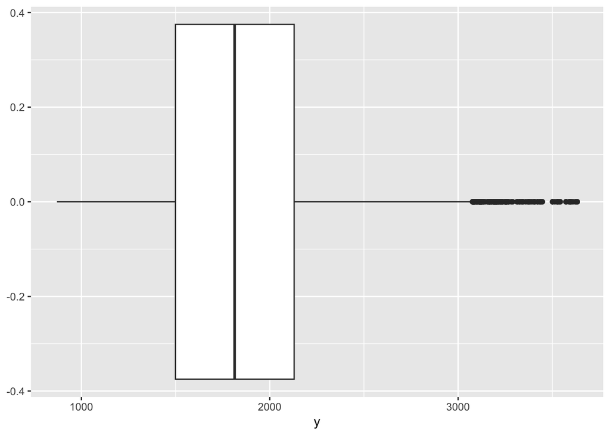

Eksik değer bulunmuyor.

```r
colSums(is.na(df))
```

```
## ds  y
##  0  0
```

```r
if (anyNA(df)) {
  print("Eksik değerler var.")
} else {
  print("Eksik değer yok.")
}
```

```
## [1] "Eksik değer yok."
```

```r
df$ds <- as.Date(df$ds)
```

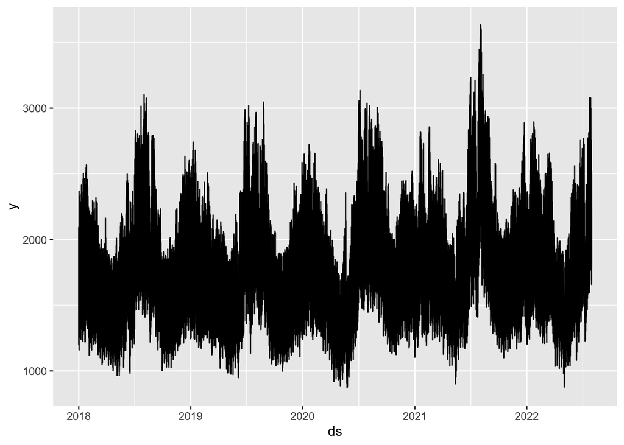

```r
ggplot(df , aes(x =ds, y = y)) + geom_line()
```

Tahminleri aylık bazda yapmak istediğimiz için aylık bazda y’nin toplamını alarak veriyi aggregate ettik.

```r
df = df %>%
  mutate(ds = floor_date(ds, unit = "month")) %>%
  group_by(ds) %>%
  summarise(y = sum(y, na.rm = TRUE))
```

Verideki ilk gün 2018 Ocak ayını temsilen 2018-01-01, son gün 2022-07-01.

```
##        ds                   y
##  Min.   :2018-01-01   Min.   :1060817
##  1st Qu.:2019-02-15   1st Qu.:1205186
##  Median :2020-04-01   Median :1289557
##  Mean   :2020-03-31   Mean   :1340935
##  3rd Qu.:2021-05-16   3rd Qu.:1458256
##  Max.   :2022-07-01   Max.   :1793768
```

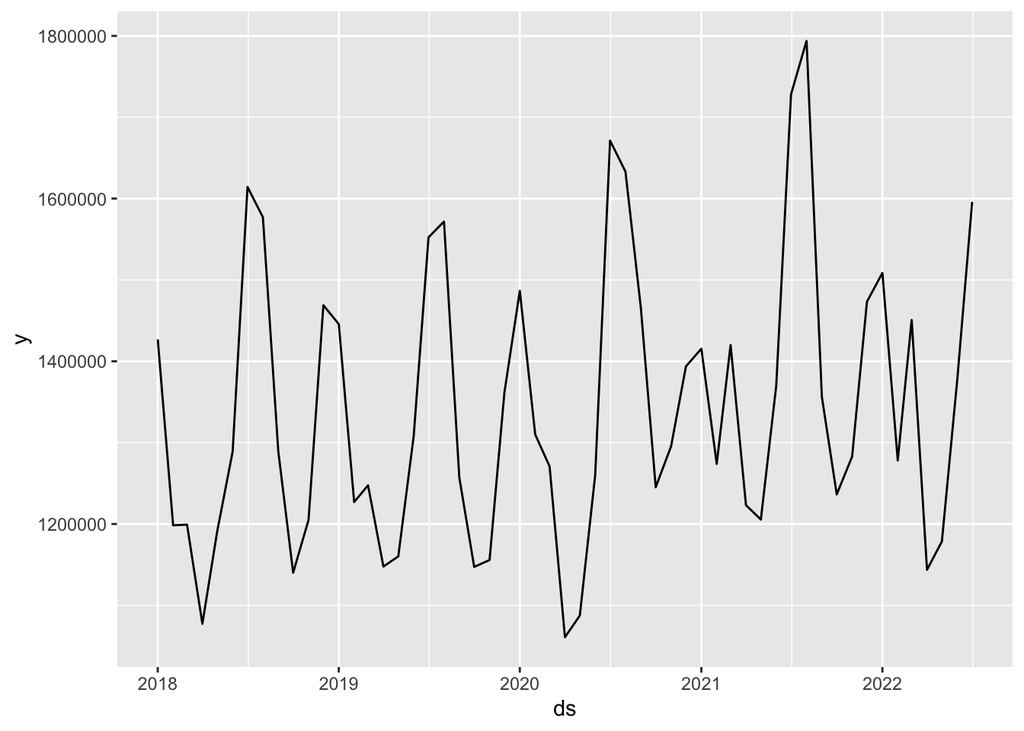

```r
ggplot(df , aes(x =ds, y = y)) + geom_line()
```

**Decomposition**

Yıl içinde aynı dalgalanma her sene görüldüğü için mevsimsellik var ve veri seti randomluk barındırıyor.Veri seti durağan değildir.

Veri setinde yükselen trend görünüyor. Artan trend ile birlikte dalgaların şiddeti de arttığı için çarpımsal bir modeldir diyoruz.

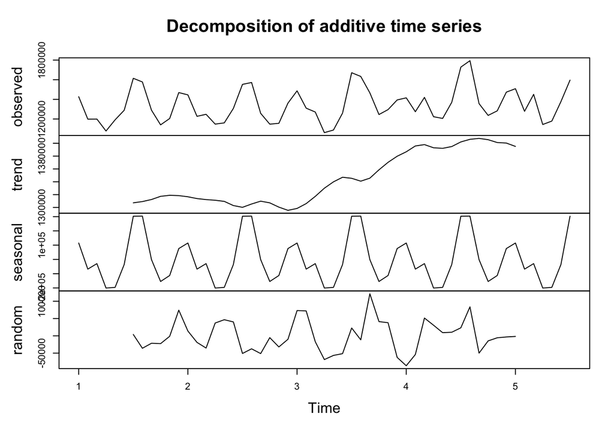

```r
decomp = decompose(ts(df$y,frequency = 12))
plot(decomp)
```

**Train- test seti ayırma**

İlk 52 gözlemi eğitim için ayırıp son 3 gözlemi tahmin için ayırıyoruz.

```r
train_set_arima = head(df, n = 52)
test_set_arima = tail(df, n = 3)
test_set_arima
```

```
## # A tibble: 3 × 2
##   ds                y
##   <date>        <dbl>
## 1 2022-05-01 1178572.
## 2 2022-06-01 1377149.
## 3 2022-07-01 1595943.
```

```r
# Veri setininin türünü ts yapıyoruz.
df_ts = ts(train_set_arima$y, frequency = 12, start =c(2018,1))
```

**1 normal fark alma (lag=1)**

Veriyi durağanlaştırmak için 1 fark aldık ve trend ortadan kalktı. Hala mevsimsellik etkisi görünüyor.

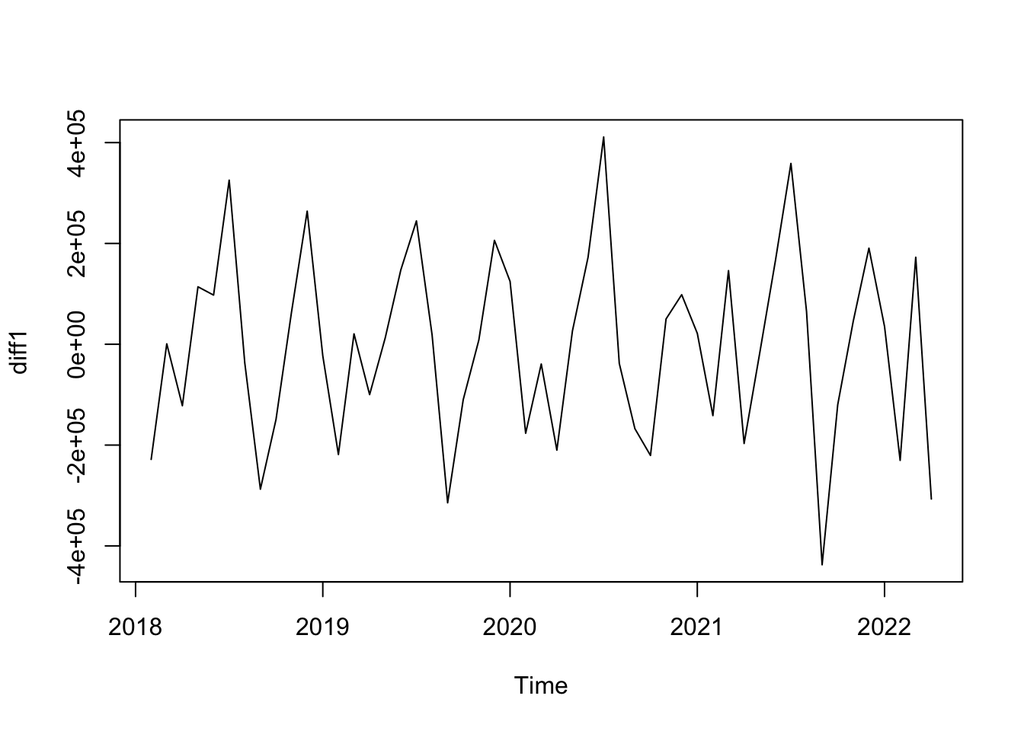

```r
diff1 = diff(df_ts, 1)
plot.ts(diff1)
```

**Mevsimsel fark alma (lag=12)**

12 fark aldığımızda mevsimselliğin düzeni bozuldu.

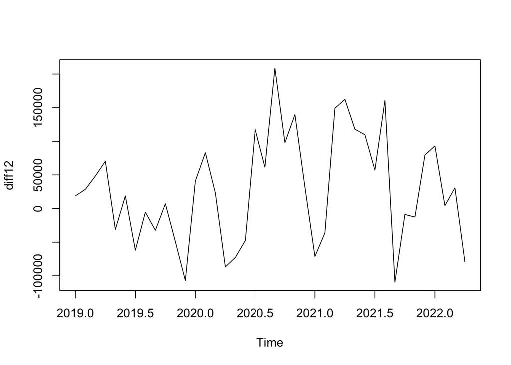

```r
diff12 = diff(df_ts, 12)
plot.ts(diff12)
```

**1 normal 1 mevsimsel fark alma (lag=1) (lag=12)**

1 normal fark ve 1 mevsimsel fark (12) aldığımızda 2021 Ağustos gibi bir etki görünüyor ancak onun dışında mevsimsellik ortadan kalkmıştır. Emin olmak için orokorelasyonlarını çizdireceğiz.

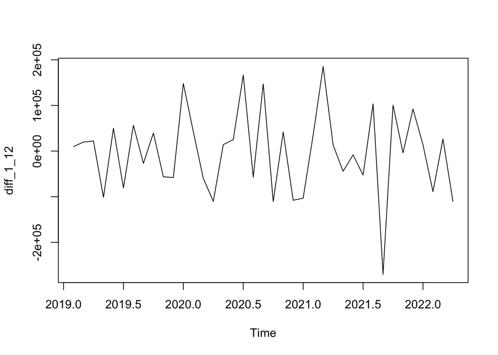

```r
diff_1_12 = diff(diff1, 12)
plot.ts(diff_1_12)
```

**Mevsimsel fark alınan veri setinde ACF / PACF**

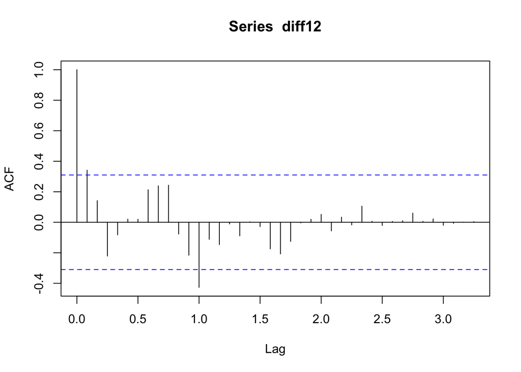

```r
acf(diff12, lag.max =50)
```

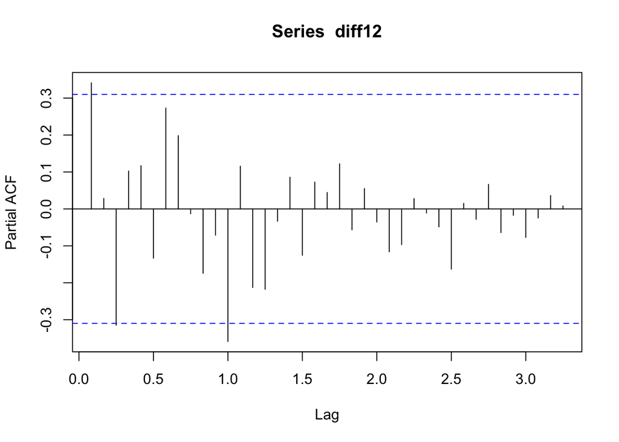

```r
pacf(diff12, lag.max =50)
```

**Mevsimsel ve normal fark alınan veri setinde ACF / PACF**

Seasonal kısmına baktığımızda ACF 1.0 noktasından 2.0 noktasına cutt off olmuş.

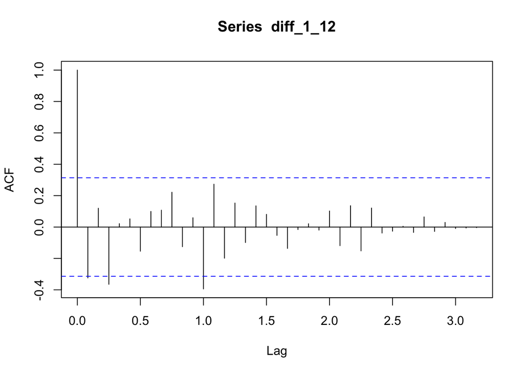

```r
acf(diff_1_12, lag.max =50)
```

Seasonal açıdan baktığımızda PACF durağan gözüküyor.

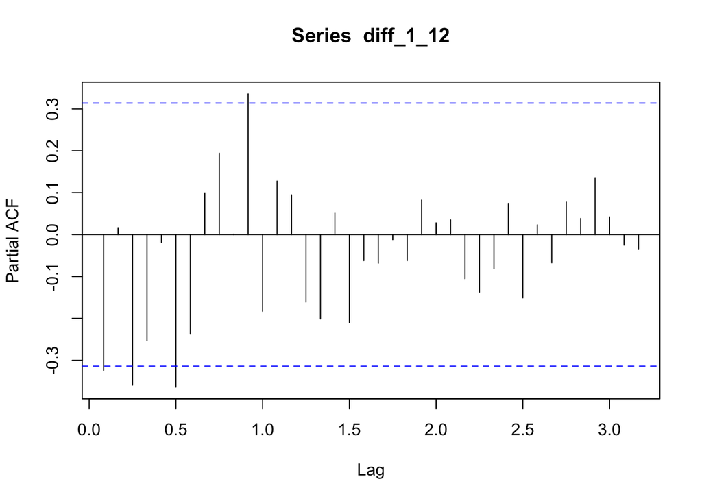

```r
pacf(diff_1_12, lag.max =50)
```

**Stationary test**

Durağanlıktan emin olmak için ADF test yapıyoruz. Bu testten geçtiği için 1 normal 1 mevsimsel fark alınmış veriyle devam ediyoruz.

```
##
##  Augmented Dickey-Fuller Test
##
## data:  diff_1_12
## Dickey-Fuller = -4.8607, Lag order = 3, p-value = 0.01
## alternative hypothesis: stationary
```

## ARIMA Uygulaması

Yapılan denemeler sonucunda (p,d,q) (P,D,Q) değerleri sırasıyla (1,1,1)(0,1,1) olacak şekilde ayarlanmıştır.

```r
ts_model = arima(diff_1_12,  order = c(1, 1, 1), seasonal = list(order = c(0, 1, 1), period = 12))
ts_model
```

```
##
## Call:
## arima(x = diff_1_12, order = c(1, 1, 1), seasonal = list(order = c(0, 1, 1),
##     period = 12))
##
## Coefficients:
##           ar1      ma1     sma1
##       -0.2902  -1.0000  -0.9999
## s.e.   0.1850   0.1518   0.4597
##
## sigma^2 estimated as 9.862e+09:  log likelihood = -345.1,  aic = 698.19
```

**Coef Test**

Model parametrelelerinin anlamlılığını test edelim.

```
##
## z test of coefficients:
##
##      Estimate Std. Error z value  Pr(>|z|)
## ar1  -0.29022    0.18497 -1.5690   0.11665
## ma1  -1.00000    0.15177 -6.5891 4.425e-11 ***
## sma1 -0.99993    0.45969 -2.1752   0.02961 *
## ---
## Signif. codes:  0 '***' 0.001 '**' 0.01 '*' 0.05 '.' 0.1 ' ' 1
```

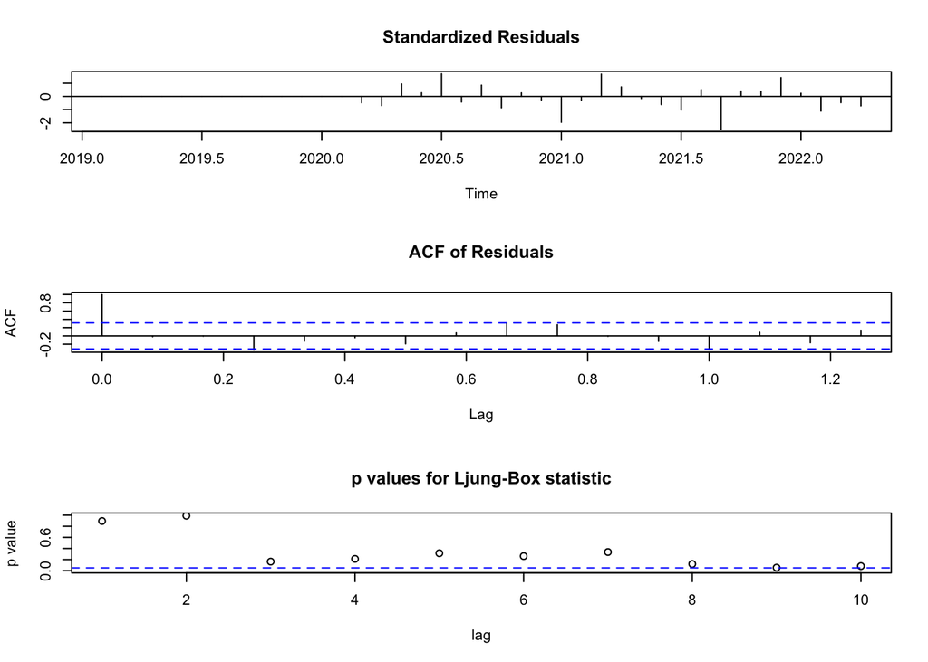

*H0 : Otokorelasyın yok.*

*HI: Otokorelasyon var.*

Box teste baktığımızda lag 6,12,24,36 p valuelarının hepsi 0.05’den büyük olduğu için hepsi anlamlı çıkıyor.

```r
Box.test(ts_model$residuals, lag = 6)
```

```
##
##  Box-Pierce test
##
## data:  ts_model$residuals
## X-squared = 6.5973, df = 6, p-value = 0.3597
```

```r
Box.test(ts_model$residuals, lag = 12)
```

```
##
##  Box-Pierce test
##
## data:  ts_model$residuals
## X-squared = 17.475, df = 12, p-value = 0.1326
```

```r
Box.test(ts_model$residuals, lag = 24)
```

```
##
##  Box-Pierce test
##
## data:  ts_model$residuals
## X-squared = 21.738, df = 24, p-value = 0.5949
```

```r
Box.test(ts_model$residuals, lag = 36)
```

```
##
##  Box-Pierce test
##
## data:  ts_model$residuals
## X-squared = 21.75, df = 36, p-value = 0.9707
```

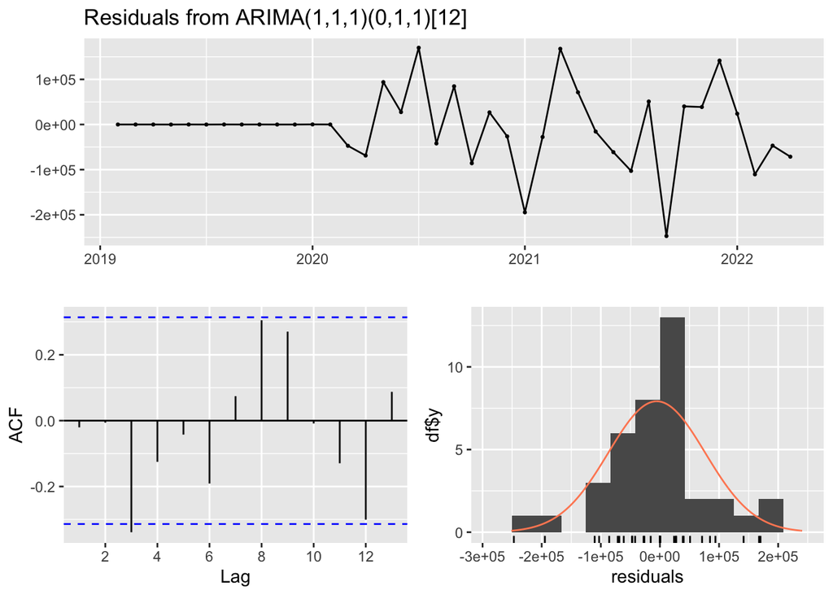

```
##
##  Ljung-Box test
##
## data:  Residuals from ARIMA(1,1,1)(0,1,1)[12]
## Q* = 12.763, df = 5, p-value = 0.0257
##
## Model df: 3.   Total lags used: 8
```

```r
library("forecast")

checkresiduals(ts_model)
```

**Auto ARIMA ile Karşılaştırma**

Deneyerek belirlediğimiz ve bulduğumuz en iyi model ile auto arimadan çıkan en iyi modeli karşılaştıralım.

```r
auto_model <- auto.arima(diff_1_12)
print(auto_model)
```

```
## Series: diff_1_12
## ARIMA(1,0,1)(1,0,0)[12] with zero mean
##
## Coefficients:
##          ar1      ma1     sar1
##       0.3762  -0.9847  -0.5234
## s.e.  0.1846   0.4350   0.1395
##
## sigma^2 = 4.403e+09:  log likelihood = -490.2
## AIC=988.41   AICc=989.58   BIC=995.06
```

```r
ts_model
```

```
##
## Call:
## arima(x = diff_1_12, order = c(1, 1, 1), seasonal = list(order = c(0, 1, 1),
##     period = 12))
##
## Coefficients:
##           ar1      ma1     sma1
##       -0.2902  -1.0000  -0.9999
## s.e.   0.1850   0.1518   0.4597
##
## sigma^2 estimated as 9.862e+09:  log likelihood = -345.1,  aic = 698.19
```

```r
# ARIMA(1, 1, 1)(0, 1, 1)
```

Modelimizin AIC değeri Auto ARIMA modelini AIC değerinden ddaha küçük, log likelihood ise daha büyük olduğu için oluşturduğumuz model ile devam edeceğiz.

**Prediction**

3 aylık zaman periyodu için tahmin yapalım.

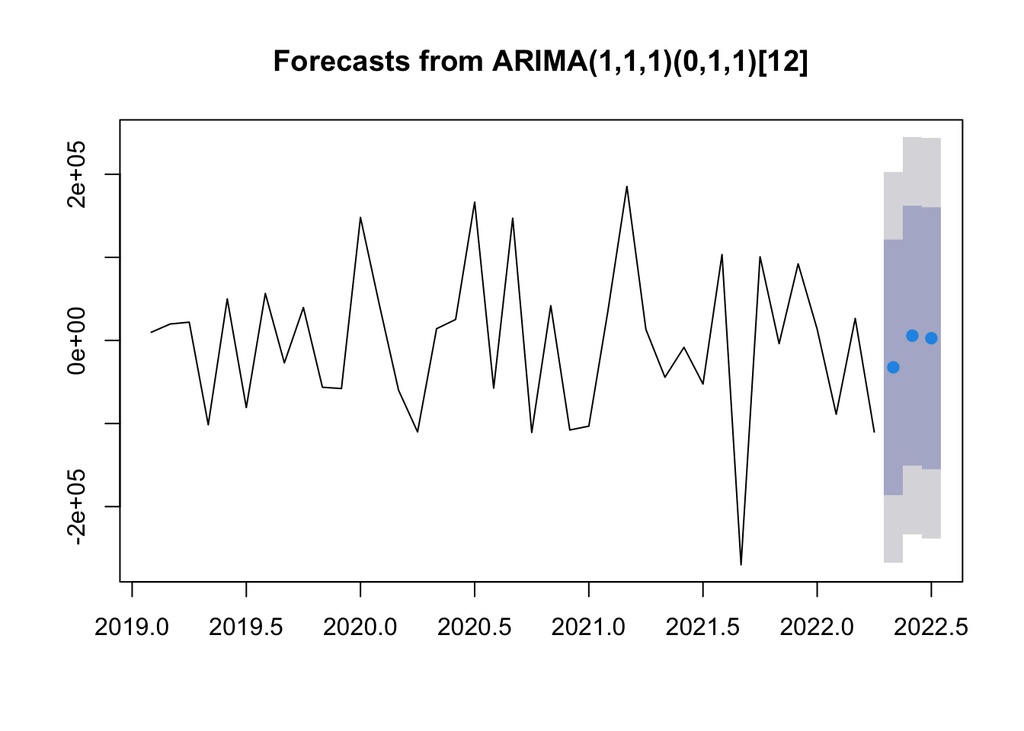

```r
library('forecast')
pred_arima = forecast(ts_model, h=3)
plot(pred_arima)
```

**Metriklerin bulunması**

```r
point_pred <- pred_arima[4]$mean

# RMSE değeri:
rmse_arima = sqrt(mean((test_set_arima$y - point_pred)^2))
# R2 Değeri:
r2_arima = (cor(test_set_arima$y , point_pred)[1])^2 %>% round (4)
```

## LSTM Uygulaması

**Veri normalizasyonu**

Veriyi scale etmek için fonksiyonlarımızı hazırlıyoruz.

```r
get_scaling_factors <- function(data){
  out <- c(mean = mean(data), sd = sd(data))
  return(out)
}

normalize_data <- function(data, scaling_factors, reverse = FALSE) {

  if (reverse) temp <- (data * scaling_factors[2]) + scaling_factors[1]
  else temp <- (data - scaling_factors[1]) / scaling_factors[2]

  out <- temp %>% as.matrix()
  return(out)
}
```

**Veri hazırlama**

LSTM verileri 3 boyutlu [samples, timesteps, features] fotmatta alır. Buna uygun olarak aşağıdaki fonksyon ile hazırlayacağız.

Gecikmeleri lag değeri, gelecek tahmin periyodunu da pred değişkenleri ile belirteceğiz.

```r
kerasize_data <- function(data, x = TRUE, lag = 3, pred = 3) {

  if (x) {

    temp <- sapply(
      1:(length(data) - lag - pred + 1)
      ,function(x) data[x:(x + lag - 1), 1]
    ) %>% t()

    out <- array(
      temp %>% unlist() %>% as.numeric()
      ,dim = c(nrow(temp), lag, 1)
    )

  }  else {

    temp <- sapply(
      (1 + lag):(length(data) - pred + 1)
      ,function(x) data[x:(x + lag - 1), 1]
    ) %>% t()

    out <- array(
      temp %>% unlist() %>% as.numeric()
      ,dim = c(nrow(temp), pred, 1)
    )

  }

  return(out)

}

kerasize_pred_input <- function(data, lag = 3, pred = 3){
  temp <- data[(length(data) - pred + 1):length(data)]
  temp <- normalize_data(temp, get_scaling_factors(data))
  out <- array(temp, c(1, lag, 1))
  return(out)
}
```

Model kurmak için gerekli olan fonksiyonumuzu hazırlıyoruz.

```r
lstm_build_model <- function(x, y, units = 10, batch = 1, epochs = 20, rate = 0.5, seed = 42){

  lag = dim(x)[2]

  lstm_model <- keras_model_sequential()

  lstm_model %>%
    layer_lstm(units = units
               ,batch_input_shape = c(batch, lag, 1)
               ,return_sequences = TRUE
               ,stateful = TRUE) %>%
    layer_dropout(rate = rate) %>%
    layer_lstm(units = units
               ,return_sequences = TRUE
               ,stateful = TRUE) %>%
    layer_dropout(rate = rate) %>%
    time_distributed(layer_dense(units = 1))

  lstm_model %>%
    compile(loss = 'mae'
            ,optimizer = 'adam'
            ,metrics = 'accuracy')

  tensorflow::set_random_seed(seed)
  lstm_model %>% fit(
    x = x
    ,y = y
    ,batch_size = batch
    ,epochs = epochs
    ,verbose = 0
    ,shuffle = FALSE)

  out <- list(
    model = lstm_model
    ,x = x
    ,batch = batch
    ,lag = lag
    ,pred = dim(y)[2]
  )
  return(out)

}
```

Tahmin yapmak için fonksiyonumuzu hazırlıyoruz.

```r
lstm_forecast <- function(x_test, model, scaling_factors){

  batch <- model$batch

  temp <- model$model %>%
    predict(x_test, batch_size = batch) %>%
    .[, , 1] %>%
    normalize_data(scaling_factors = scaling_factors, reverse = TRUE)

  out <- list(
    forecast = temp
    ,scaling_factors = scaling_factors
  )

  return(out)

}
```

Elimizdeki veri setinden tarih ve hedef (y) sütunlarını alıyoruz.

```r
data = df[c("ds","y")]
```

Model için veri setimizi hazırlıyoruz.

```r
scaling_factors <- get_scaling_factors(data$y)
data_normalized <- normalize_data(data$y, scaling_factors)

x_data <- kerasize_data(data_normalized,  x = TRUE)
y_data <- kerasize_data(data_normalized, x = FALSE)
x_test <- kerasize_pred_input(data_normalized)
```

**Model kurma aşaması**

lstm_build_model fonksiyonu ile modeli oluşturup model değişkenine atıyoruz.

```r
model <- lstm_build_model(x_data, y_data)
```

```r
model
```

```
## $model
## Model: "sequential"
## ________________________________________________________________________________
##  Layer (type)                       Output Shape                    Param #
## ================================================================================
##  lstm_1 (LSTM)                      (1, 3, 10)                      480
##  dropout_1 (Dropout)                (1, 3, 10)                      0
##  lstm (LSTM)                        (1, 3, 10)                      840
##  dropout (Dropout)                  (1, 3, 10)                      0
##  time_distributed (TimeDistributed)  (1, 3, 1)                      11
## ================================================================================
## Total params: 1,331
## Trainable params: 1,331
## Non-trainable params: 0
## ________________________________________________________________________________
##
## $x
## , , 1
##
##              [,1]        [,2]        [,3]
##  [1,]  0.49248890 -0.81665101 -0.81197251
##  [2,] -0.81665101 -0.81197251 -1.51049009
##  [3,] -0.81197251 -1.51049009 -0.85717487
##  [4,] -1.51049009 -0.85717487 -0.29852453
##  [5,] -0.85717487 -0.29852453  1.56650372
##  [6,] -0.29852453  1.56650372  1.35314513
##  [7,]  1.56650372  1.35314513 -0.29440563
##  [8,]  1.35314513 -0.29440563 -1.15060103
##  [9,] -0.29440563 -1.15060103 -0.77951395
## [10,] -1.15060103 -0.77951395  0.73330175
## [11,] -0.77951395  0.73330175  0.60005920
## [12,]  0.73330175  0.60005920 -0.65307480
## [13,]  0.60005920 -0.65307480 -0.53498372
## [14,] -0.65307480 -0.53498372 -1.10748048
## [15,] -0.53498372 -1.10748048 -1.03544329
## [16,] -1.10748048 -1.03544329 -0.19051721
## [17,] -1.03544329 -0.19051721  1.21161333
## [18,] -0.19051721  1.21161333  1.32224760
## [19,]  1.21161333  1.32224760 -0.47990925
## [20,]  1.32224760 -0.47990925 -1.10956377
```

[output cut: 25 more lines]

```
## [46,] -0.59904454 -0.33292127  0.75892231
## [47,] -0.33292127  0.75892231  0.96034960
## [48,]  0.75892231  0.96034960 -0.35959009
## [49,]  0.96034960 -0.35959009  0.62908576
## [50,] -0.35959009  0.62908576 -1.13019634
##
##
## $batch
## [1] 1
##
## $lag
## [1] 3
##
## $pred
## [1] 3
```

**Öngörü yapma aşaması**

```r
prediction <- lstm_forecast(x_test, model, scaling_factors)
prediction
```

```
## $forecast
##         [,1]
## [1,] 1392100
## [2,] 1384881
## [3,] 1363707
##
## $scaling_factors
##      mean        sd
## 1340934.7  174512.1
```

Daha sonra karşılaştırmak için hata metriklerini bulalım.

```r
# RMSE değeri:
rmse_lstm = sqrt(mean((tail(data$y, n =3) - prediction$forecast)^2))
# R2 Değeri:
r2_lstm = (cor((tail(data$y, n =3)) , prediction$forecast)[1])^2 %>% round (4)
```

## Sonuç Karşılaştırma

```
## [1] "LSTM modelinin RMSE değeri  182197.114845392 SARIMA modelinin RMSE değeri ise  1400676.74990977"
```

```
## [1] "LSTM modelinin R2 değeri  0.9395 SARIMA modelinin R2 değeri ise  0.6579"
```

LSTM’in R2 değeri daha yüksek ancak bu yanıltıcı, çünkü ortalama bir çizgi çekiyor. Aşağıdaki LSTM tahmin plotuna baktığımızda da ortalama değerlerle kabaca bir tahmin yaptığını görüyoruz.

**Seasonal ARIMA Tahminleri**

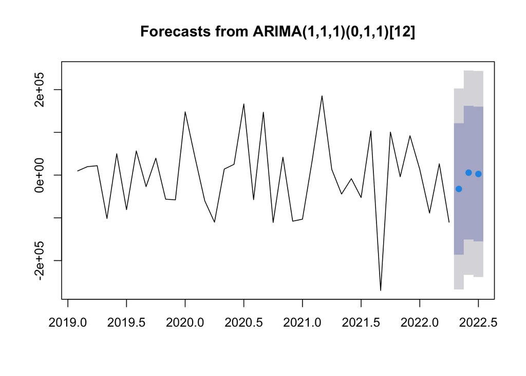

**LSTM Tahminleri**

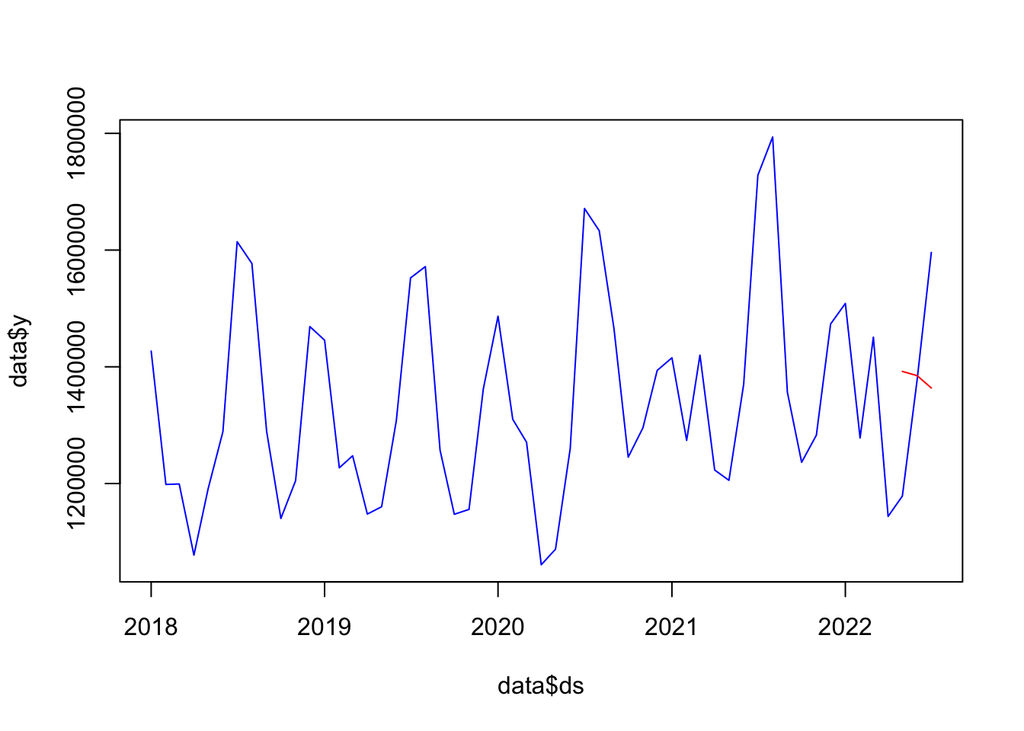

#### Kaynaklar:

- https://stats.stackexchange.com/questions/445014/how-to-set-p-d-q-and-p-d-q-for-sarima-time-series-model
- https://autobox.com/pdfs/ARIMA%20FLOW%20CHART.pdf
- https://online.stat.psu.edu/stat510/lesson/4/4.1
- https://arauto.readthedocs.io/en/latest/how_to_choose_terms.html
- https://rpubs.com/pawel-wieczynski/891765
- http://rwanjohi.rbind.io/2018/04/05/time-series-forecasting-using-lstm-in-r/